# starter_pack_peru

# 1 Starter Pack: Flood risk in Ica, Peru

This contains the code and documentation for a flood risk analysis for the city of Ica, Peru. The notebooks explore impacts on housing, people and roads.

## 1.1 Setup

- Clone this repository to your local machine, or download a ZIP of this folder by clicking the green ‘Code’ dropdown above followed by the ‘Download ZIP’ button.
- Set up a virtual environment with CLIMADA installed. The CLIMADA [Getting Started](https://climada-python.readthedocs.io/en/stable/getting-started/index.html) guide explains how.
- If necessary, set up Jupyter notebooks. You can look up how do this at a system level, which allows the functionality to be reused across environments, or on the command line you can activate your virtual environment (covered in the guide linked above) and run `mamba install jupyter` (you can replace `mamba` with `conda` or with the relevant installation instruction for your environment manager.)
- Either: Open the folder in your preferred development environment and activate the virtual environment. OR: from the command line activate your virtual environment (covered in the guide linked above) and run `jupyter notebook`.
- Run these notebooks. You may need to edit the filepaths at the start of each file. Throughout the notebooks parameters can be changed, and datasets can be modified and improved. We encourage you to explore.

## 1.2 Structure

- The data/ folder contains all the required input data
- The notebooks/ folder goes through the risk analysis step by step:
  - 01_entity_exposures.ipynb – Mapping the exposed assets
  - 02_entity_impact_functions.ipynb – Visualising the impact functions
  - 03_hazard.ipynb – Mapping the hazard data
  - 04_uncalibrated_risk.ipynb – Running a risk calculation with the uncalibrated data
  - 05_observations.ipynb - Processing observations required for return-period-based calibration
  - 06a_calibration_residential.ipynb - Calibrating the risk calculation for housing
  - 07_future_risk.ipynb - Adding future hazard and exposure data and quantifying the change in risk
- starter_pack_peru.html contains these notebooks and their output in a single HTML file

## 1.3 Contributing

This analysis is intended to support teaching materials and is still under development. If any of the code doesn’t work, if something could be added to improve the analysis, or if something could be explained more clearly, please let us know. You can do this by creating a GitHub Issue, or by contacting us by email.

# 2 Exposed assets

In this notebook we read Entity files for Ica, Peru and visualize the Exposures data for housing, people and roads.

## 2.1 Read Exposures from Entity files

The `climada.entity` package provides the tools to interact with Entity files.

Exposure data must be stored in the *first sheet* of the Excel workbook, called ‘assets’ by convention. The exposure data is stored in the Entity’s `exposures` attribute, and is an instance of CLIMADA’s [Exposures](https://climada-python.readthedocs.io/en/v6.1.0/user-guide/climada_entity_Exposures.html) class. They don’t need to be financial: the units are specified within the file.

Let’s set up our project folders and read in the file(s). This notebook (and the following notebooks) is set up to explore a list of different Entity files, each containing a different asset type.

**NOTE:** You can also create Exposures objects from pandas DataFrames, geopandas GeoDataframes, other Excel files, CSVs, HDF5 files, and raster (e.g. TIF) data. See the [CLIMADA User Guide](https://climada-python.readthedocs.io/en/v6.1.0/user-guide/climada_entity_Exposures.html) for the different ways to do this.

```python
from climada.entity import Entity
from pathlib import Path

# Set the directory where our Entity files are located
ENTITY_DIR = "../data/entity_files_uncalibrated/"
# Give a list of Entity file names (so we can examine more than one file if we want)
ENTITY_FILES = ["ICA_PERU_Entity_Floods_Residential.xlsx", "ICA_PERU_Entity_Floods_People.xlsx", "ICA_PERU_Entity_Floods_Road.xlsx"]

entity_filepaths = [Path(ENTITY_DIR) / filename for filename in ENTITY_FILES]
```

```python
# Read in the files
entity_list = []
for filepath in entity_filepaths:
    print(f"Reading {filepath.name}...")
    entity = Entity.from_excel(filepath)

    # After reading in the file, it is a good idea to set additional properties of the Exposures object

    # ref_year:
    # We can optionally set a reference year for the entity, which describes the year (past, present or future) that the data represent.
    # This is required when the Exposures are used in a cost-benefit analysis, comparing risk at two different points in time.
    entity.exposures.ref_year = 2026

    # value_unit:
    # The unit of the exposure values. This needs to be specified but will be read from the Excel file after the next release
    entity.exposures.value_unit = "People" if "People" in filepath.name else "USD"

    # description:
    # Optional – used for creating plot titles
    entity.exposures.description = f"Exposures from {filepath.name}"

    entity_list.append(entity)


# We can then store the exposures in their own list by accessing the `exposures` property:
exposures_list = [entity.exposures for entity in entity_list]
```

```
Reading ICA_PERU_Entity_Floods_Residential.xlsx...
Reading ICA_PERU_Entity_Floods_People.xlsx...
Reading ICA_PERU_Entity_Floods_Road.xlsx...
```

## 2.2 Exposures properties

The Excel sheets we just read in are stored in the `Exposures.gdf` (=‘GeoDataFrame’) attribute. We can print some summary information about the Exposures we’re working with:

```python
from IPython.display import display

for exp in exposures_list:
    print("")
    print(exp.description)
    print(f"- The Exposures consists of {len(exp.gdf)} points")
    print(f"- Their total value is {exp.gdf['value'].sum():,.0f} {exp.value_unit}")
    print(f"- The points lie between latitudes {exp.latitude.min():.2f} and {exp.latitude.max():.2f}")
    print(f"- The points lie between longitudes {exp.longitude.min():.2f} and {exp.longitude.max():.2f}")
    # If there is region information
    if "region_id" in exp.gdf.columns:
        print(f" -The exposure contains {exp.gdf['region_id'].nunique()} region id(s)")
    # If there is category information
    if "category_id" in exp.gdf.columns:
        print(f"- The exposure contains {exp.gdf['category_id'].nunique()} category id(s)")
    # Find information about impact functions – the column names for these depend on the hazard type
    for col in exp.gdf.columns:
        if col.startswith("impf_"):
            print(f"- The exposure uses {exp.gdf[col].nunique()} different impact functions (column: '{col}')")

for exp in exposures_list:
    print('\n' + exp.description + ' (first 5 rows)')
    display(exp.gdf.head())
```

```
Exposures from ICA_PERU_Entity_Floods_Residential.xlsx
- The Exposures consists of 107016 points
- Their total value is 7,863,601,676 USD
- The points lie between latitudes -14.16 and -13.96
- The points lie between longitudes -75.76 and -75.66
 -The exposure contains 1 region id(s)
- The exposure contains 1 category id(s)
- The exposure uses 1 different impact functions (column: 'impf_FL')

Exposures from ICA_PERU_Entity_Floods_People.xlsx
- The Exposures consists of 107016 points
- Their total value is 190,413 People
- The points lie between latitudes -14.16 and -13.96
- The points lie between longitudes -75.76 and -75.66
 -The exposure contains 1 region id(s)
- The exposure contains 1 category id(s)
- The exposure uses 1 different impact functions (column: 'impf_FL')

Exposures from ICA_PERU_Entity_Floods_Road.xlsx
- The Exposures consists of 18640 points
- Their total value is 295,276,000 USD
- The points lie between latitudes -14.16 and -13.94
- The points lie between longitudes -75.76 and -75.60
 -The exposure contains 1 region id(s)
- The exposure contains 1 category id(s)
- The exposure uses 1 different impact functions (column: 'impf_FL')

Exposures from ICA_PERU_Entity_Floods_Residential.xlsx (first 5 rows)
```

|  | category_id | region_id | housing_count | value | deductible | cover | impf_FL | value_unit | geometry |
| --- | --- | --- | --- | --- | --- | --- | --- | --- | --- |
| 0 | 1 | 1 | 1 | 97397.744233 | 0 | NaN | 101 | USD | POINT (-75.73100 -14.06785) |
| 1 | 1 | 1 | 1 | 97397.744233 | 0 | NaN | 101 | USD | POINT (-75.73100 -14.06770) |
| 2 | 1 | 1 | 1 | 97397.744233 | 0 | NaN | 101 | USD | POINT (-75.73100 -14.06756) |
| 3 | 1 | 1 | 1 | 97397.744233 | 0 | NaN | 101 | USD | POINT (-75.73100 -14.06741) |
| 4 | 1 | 1 | 1 | 97397.744233 | 0 | NaN | 101 | USD | POINT (-75.73100 -14.06727) |

```
Exposures from ICA_PERU_Entity_Floods_People.xlsx (first 5 rows)
```

|  | category_id | region_id | value | deductible | cover | impf_FL | value_unit | geometry |
| --- | --- | --- | --- | --- | --- | --- | --- | --- |
| 0 | 1 | 1 | 0 | 0 | NaN | 202 | People | POINT (-75.73100 -14.06785) |
| 1 | 1 | 1 | 0 | 0 | NaN | 202 | People | POINT (-75.73100 -14.06770) |
| 2 | 1 | 1 | 0 | 0 | NaN | 202 | People | POINT (-75.73100 -14.06756) |
| 3 | 1 | 1 | 0 | 0 | NaN | 202 | People | POINT (-75.73100 -14.06741) |
| 4 | 1 | 1 | 4 | 0 | NaN | 202 | People | POINT (-75.73100 -14.06727) |

```
Exposures from ICA_PERU_Entity_Floods_Road.xlsx (first 5 rows)
```

|  | category_id | region_id | road_length (m) | value | deductible | cover | impf_FL | Value_unit | geometry |
| --- | --- | --- | --- | --- | --- | --- | --- | --- | --- |
| 0 | 1 | 1 | 15 | 15000 | 0 | NaN | 103 | USD | POINT (-75.75194 -14.08030) |
| 1 | 1 | 1 | 15 | 15000 | 0 | NaN | 103 | USD | POINT (-75.75191 -14.08044) |
| 2 | 1 | 1 | 15 | 15000 | 0 | NaN | 103 | USD | POINT (-75.75188 -14.08058) |
| 3 | 1 | 1 | 15 | 15000 | 0 | NaN | 103 | USD | POINT (-75.75186 -14.08073) |
| 4 | 1 | 1 | 15 | 15000 | 0 | NaN | 103 | USD | POINT (-75.75182 -14.08087) |

Points worth noting about the `Entity.exposures` geodataframe: - There are extra columns here that aren’t used by CLIMADA: the residential data’s ‘housing_count’ column and the road data’s ‘road_length (m)’ column. We can use these in our own code, for example if we wanted to set the ‘value’ column to something different. We will do this in the risk calculations and calibration. - The original latitude and longitude columns have been converted to a ‘geometry’ column. You can still access the raw values with the `Exposures.latitude` and `Exposures.longitude` properties - The deductible and cover columns are used when asset-level insurance is modelled as an adaptation measure – for now they should be left blank in the Excel workbook - Each exposure point is acted on by an impact function. This is defined here in the ‘impf_FL’ column. The last two letters are used to specify the hazard type (here: flood) and is used in matching between datasets. A column ‘impf_’ with no hazard type is also valid, and will match to any hazard type.

## 2.3 Visualize the Exposures: points on a map

There are a few ways to visualize an Exposures object. Simplest is to plot them as points on a map with `Exposures.plot_basemap`.

[figure not shown]

png

[figure not shown]

png

[figure not shown]

png

```python
%matplotlib inline
import contextily as ctx

for exp in exposures_list:
    exp.plot_basemap(
        title=exp.description,   # Title for the map. This is the default value.
        ignore_zero=False,       # Whether to plot points with zero value
        buffer=500,              # Add a buffer around the points to show a larger map region (measured in meters)
        s=0.5,                   # The size of point markers on the plot
        zoom=13,                 # The detail level of the map. 6 is good for a large country. 8 is good for a state or region. 13 for a city. 15 for a municipality.
        url=ctx.providers.OpenStreetMap.Mapnik,
                                 # Set a basemap using contextily – here we use OpenStreetMap which gives a more colourful mapping
                                 #     Another good option is CartoDB's Positron (the default in CLIMADA, `ctx.providers.CartoDB.Positron`)
                                 #     ... this gives a less distracting basemap
                                 #     See all options at: https://xyzservices.readthedocs.io/en/stable/gallery.html
        pop_name=False,          # Add the names of populated places to the map – often not necessary when you have a basemap
        vmax=None,               # Set the maximum value for the colour scale – use this if you want a consistent scale across multiple plots.
        cmap="autumn_r",         # Colour scheme to use for the points. See https://matplotlib.org/stable/tutorials/colors/colormaps.html for options.
        figsize=(8, 10)          # Dimensions of the output figure
    )
```

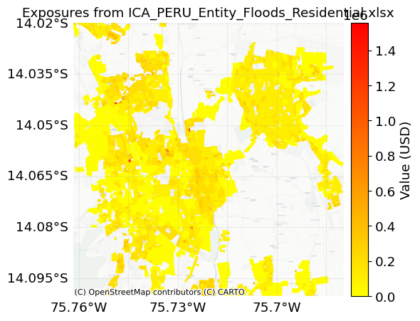

png

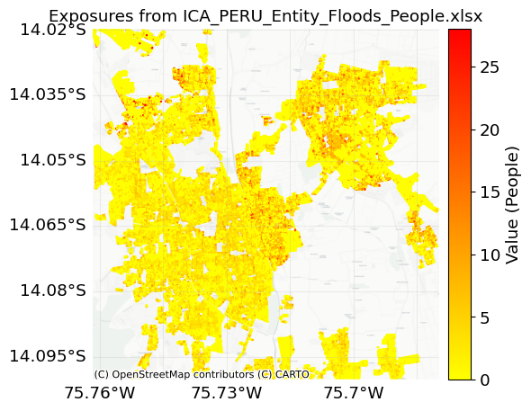

png

[figure not shown]

png

```python
# Let's zoom in and plot a smaller area:

sample_region = (-75.77, -75.68, -14.1, -14.02)  # (min_lon, max_lon, min_lat, max_lat)
lon_min, lon_max, lat_min, lat_max = sample_region

for exp in exposures_list:
    exp_zoom = exp.copy(deep=True)
    exp_zoom.set_gdf(exp_zoom.gdf.cx[lon_min:lon_max, lat_min:lat_max])
    exp_zoom.plot_basemap(
        title=exp_zoom.description,   # Title for the map. This is the default value.
        ignore_zero=False,       # Whether to plot points with zero value
        buffer=30,               # Add a buffer around the points to show a larger map region (measured in meters)
        s=0.5,                     # The size of point markers on the plot
        zoom=16,                 # The detail level of the map. 6 is good for a large country. 8 is good for a state or region. 13 for a city. 15 for a municipality.
        pop_name=False,          # Add the names of populated places to the map – often not necessary when you have a basemap
        vmax=None,               # Set the maximum value for the colour scale – use this if you want a consistent scheme across multiple plots.
        cmap="autumn_r",         # Colour scheme to use for the points. See https://matplotlib.org/stable/tutorials/colors/colormaps.html for options.
        figsize=(6, 8)           # Dimensions of the output figure
    )
```

## 2.4 Visualize Exposures: hexmap

When there are a lot of Exposure points, plotting them all on a map can obscure information because they overlap too much.

In this case aggregating the exposures to create a hexmap is useful. You can specify whether you’d like each hex to display the sum (most common) of the points within it, or some other function, e.g. mean or max.

[figure not shown]

png

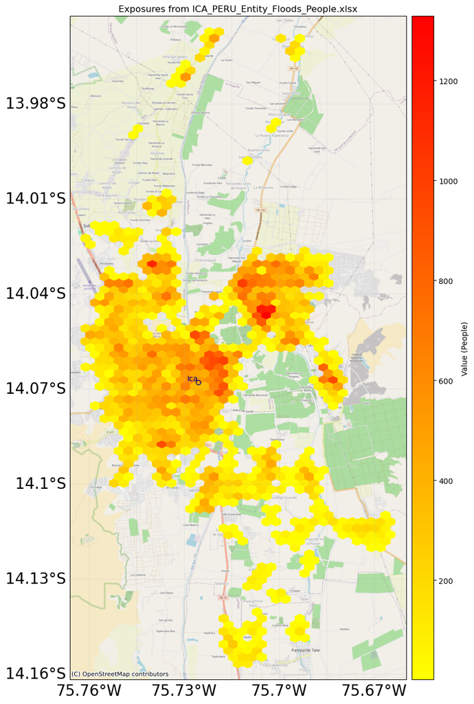

png

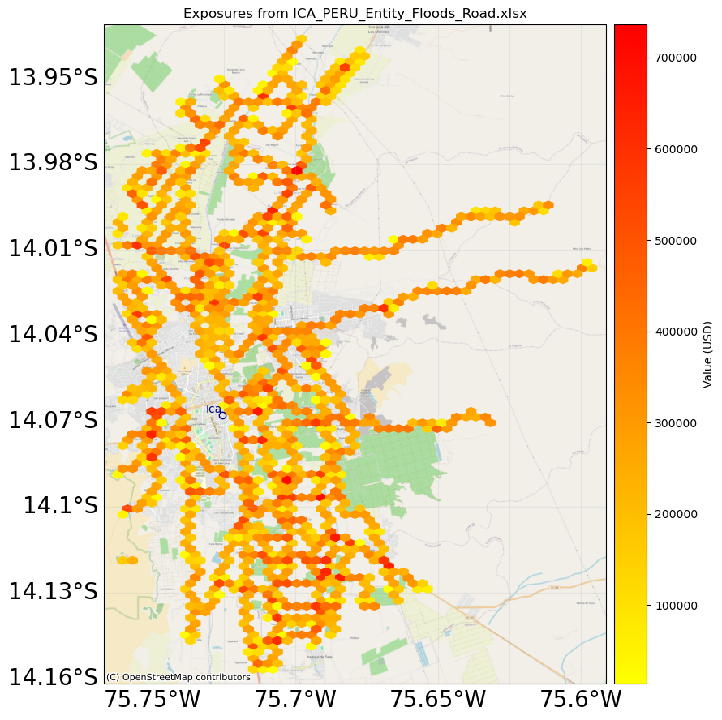

png

```python
import numpy as np
import cartopy.crs as ccrs
from climada.util import plot as u_plot

for exp in exposures_list:
    # (Optional) Set the number of bins in each direction of the map
    bin_size = 0.004  # The size of the hexagonal bins in units of latitude and longitude
    xmin, xmax = exp.longitude.min(), exp.longitude.max()
    ymin, ymax = exp.latitude.min(), exp.latitude.max()
    dim_x = int((xmax - xmin) / bin_size) + 8  # The binning isn't perfect, so we manually adjust this to make it look better
    dim_y = int((ymax - ymin) / bin_size)

    # (Optional) standardise projections and create a basemap
    proj_plot = ccrs.PlateCarree(central_longitude=0.5 * (xmin + xmax))  # Setting a central longitude allows us to plot data that crosses the 180 degree antimeridian – not so relevant here
    _, axis, fontsize = u_plot.make_map(
                proj=proj_plot, figsize=(9, 13), adapt_fontsize=True
            )

    # Plot the hexbin
    axis = exp.plot_hexbin(
        ignore_zero=True,         # Whether to plot points with zero value
        pop_name=True,            # Add the names of populated places to the map
        buffer=0.005,              # Add a buffer around the points to show a larger map region (measured in units of latitude and longitude) (different from `plot_basemap`!)
        axis=axis,
        figsize=(8, 10),
        title=exp.description,    # Title for the map. This is the default value.
        reduce_C_function=np.sum, # How to aggregate the individual exposure points to the hexagonal bins. They are summed like this by default, but you could also use np.mean, np.median, etc.
        gridsize=(dim_x, dim_y),              # The number of hexagons to use in the x-direction across the generated map
        cmap="autumn_r",          # Colour scheme to use for the points. See https://matplotlib.org/stable/tutorials/colors/colormaps.html for options.
    )
    # Add a basemap – see the previous cell for details on how to customize this
    ctx.add_basemap(axis, zoom=14, source=ctx.providers.OpenStreetMap.Mapnik, origin="upper", crs=proj_plot)
```

# 3 Impact functions

In this notebook we read Entity files for Ica, Peru and plot (uncalibrated) Impact Functions for housing, people and roads.

## 3.1 Impact functions from the Entity file

Impact functions describe the relationship between the intensity of a hazard and its effect on your chosen exposure.

They are stored in the Entity Excel workbook in the ‘impact_functions’ sheet. The sheet can specify any number of impact functions. Each function is read in and stored in an `ImpactFunc` object, which are then grouped into an `ImpactFuncSet` object and stored in the `Entity`’s `impact_funcs` attribute.

All of these classes are part of CLIMADA’s `climada.entity` package.

There are two ways to create impact functions for an analysis: from an Entity file, or programatically by constructing an `ImpactFunc` object. This notebook reads from a file. For more information on Impact Functions, see the [CLIMADA User Guide](https://climada-python.readthedocs.io/en/stable/user-guide/climada_entity_ImpactFuncSet.html).

Let’s read in the Entity files and visualize the functions:

```python
from pathlib import Path

# Set the directory where our Entity files are located
ENTITY_DIR = "../data/entity_files_uncalibrated/"
# Give a list of Entity file names (so we can examine more than one file if we want)
ENTITY_FILES = ["ICA_PERU_Entity_Floods_Residential.xlsx", "ICA_PERU_Entity_Floods_People.xlsx", "ICA_PERU_Entity_Floods_Road.xlsx"]

entity_filepaths = [Path(ENTITY_DIR) / filename for filename in ENTITY_FILES]
```

```python
from climada.entity import Entity

# Read in the files
entity_list = []
for filepath in entity_filepaths:
    print(f"Reading {filepath.name}...")
    entity = Entity.from_excel(filepath)
    entity.exposures.ref_year = 2026    # Set reference year
    entity.exposures.value_unit = "USD"
    entity.exposures.description = f"Exposures from {filepath.name}"
    entity_list.append(entity)
```

```
Reading ICA_PERU_Entity_Floods_Residential.xlsx...
Reading ICA_PERU_Entity_Floods_People.xlsx...
Reading ICA_PERU_Entity_Floods_Road.xlsx...
```

```python
HAZ_TYPE = "FL"  # This is the code we use to indicate impact functions for floods in Impact Functions

# We can then store the impact function sets in their own list:
impf_set_list = [entity.impact_funcs for entity in entity_list]

for filename, impf_set in zip(ENTITY_FILES, impf_set_list):
    print(f"There are {impf_set.size()} impact functions in {filename} with IDs {impf_set.get_ids(haz_type=HAZ_TYPE)}.")
```

```
There are 3 impact functions in ICA_PERU_Entity_Floods_Residential.xlsx with IDs [101, 102, 103].
There are 2 impact functions in ICA_PERU_Entity_Floods_People.xlsx with IDs [202, 203].
There are 1 impact functions in ICA_PERU_Entity_Floods_Road.xlsx with IDs [103].
```

png

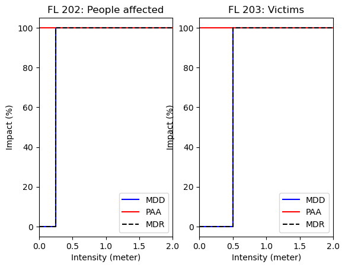

png

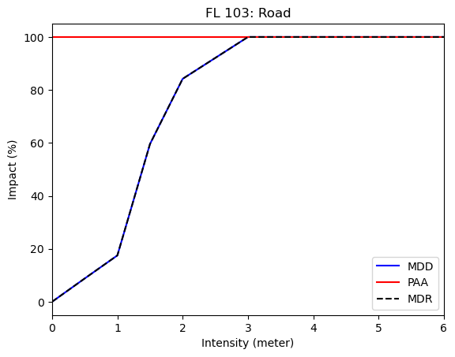

png

```python
# Visualize the impact functions
# (this can be quite messy when you have multiple functions)
for impf_set in impf_set_list:
    impf_set.plot(fun_id=None)  # Specify fun_id to plot a single function
```

An impact function is defined by the following properties:

```python
# Choose an example impact function to examine in more detail
example_impf_set = impf_set_list[0]
example_fun_ids = example_impf_set.get_ids(haz_type=HAZ_TYPE)
example_impf = example_impf_set.get_func(haz_type=HAZ_TYPE,fun_id=example_fun_ids[0])

print(f"Details from an example impact function:")
# The function ID
print(f"Function ID: {example_impf.id}")
# The hazard type ('None' is acceptable)
print(f"Hazard type: {example_impf.haz_type}")
# The intensity unit
print(f"Intensity unit: {example_impf.intensity_unit}")
# The intensity values for which damage is defined
print(f"Intensity values: {example_impf.intensity}")
# The mean damage degree values: the average damage experienced by assets at these hazard intensities
print(f"Mean damage degree values: {example_impf.mdd}")
# The percentage of assets affected: the average percentage of assets affected by this intensity of hazard at a single location
print(f"Percentage of assets affected: {example_impf.paa}")
# The name (optionally)
print(f"Name: {example_impf.name}")
```

```
Details from an example impact function:
Function ID: 101
Hazard type: FL
Intensity unit: meter
Intensity values: [0.  0.5 1.  1.5 2.  3.  4.  5.  6. ]
Mean damage degree values: [0.    0.491 0.711 0.842 0.949 0.984 1.    1.    1.   ]
Percentage of assets affected: [1 1 1 1 1 1 1 1 1]
Name: Residential loss
```

# 4 Hazard

In this notebook we read in Hazards from raster files, break down their properties and plot them.

CLIMADA describes hazards as one or more (and maybe thousands) of event footprints in a file. Each event in a Hazard object is a geospatial footprint – usually an event footprint (e.g. a historical flood depth reconstruction, or a month’s simulated drought index) or a statistical summary – usually a return period footprint (e.g. the 10-year return period wind speed).

Every event has an ID and a frequency describing how often it occurs within the framework of the analysis (e.g. annual, or 1-in-100 year probability). Together these can describe a case study, a historical event set, a daily time series, a stochastic event set, or more.

Each event footprint is defined on an underlying set of Centroids – an object containing a geodataframe of points, ensuring that all hazards are defined at the same locations (events can have zero or missing values).

Centroids are often a regular grid but don’t have to be: they can be daily climate model output, or hazard interpolated to the locations of your exposures, or defined at the locations of weather stations, or on a variable resolution grid that gives more detail in more complex or more exposed areas. Usually these will be inferred from the data source, but sometimes you need to specify them.

Hazards are in the `climada.hazard` package’s `Hazard` class and Centroids in the package’s `Centroids` class.

Hazards are stored either as .hdf5 files, written and read with CLIMADA’s own format, or (when the hazard is on a regular grid) as .tif raster files or in an xarray-compatible format (e.g. NetCDF, HDF5). In the case of a .tif file you will need to provide additional metadata when you read in the file (even IDs, event frequencies, etc).

## 4.1 Hazards from raster files

Let’s read in a raster file. You can provide a single .tif with one band for each event, or a separate .tifs file for each event. In this case we use multiple files.

```python
from climada.hazard import Hazard
from pathlib import Path

HAZARD_DIR = "../data/hazard/"
HAZARD_FILES = ["tr10_h_max_61200_4326.tif", "tr25_h_max_61200_4326.tif", "tr50_h_max_61200_4326.tif", "tr100_h_max_61200_4326.tif", "tr200_h_max_61200_4326.tif", "tr500_h_max_72000_4326.tif"]

haz_filepaths = [Path(HAZARD_DIR) / filename for filename in HAZARD_FILES]
```

### 4.1.1 Adjusting event frequencies for risk analyses

Since we’re reading from raster files, we need to provide additional metadata that’s not contained in the .tif. This includes information on the event frequency.

When we are working with return period event footprints we have to make an adjustment to the footprint frequencies to account for how CLIMADA calculates return period statistics.

The events in this event set have return periods: 10, 25, 50 years, … etc. which correspond to frequencies of occurrence of 1/10, 1/25, 1/50…

These are the correct frequencies for analysing individual events, however CLIMADA’s return period statistics are calculated on a *cumulative frequency*. That is, hazard and impact return periods are defined based on the cumulative probability of *an event like this or worse* occurring.

That means that, ranked from most to least intense, the cumulative event frequencies should match the return period frequencies.

Ranked by intensity the return period frequencies in this data are

$$\frac{1}{500}, \frac{1}{200}, \frac{1}{100}, ...$$

Adjusted, these become

$$\frac{1}{500}, (\frac{1}{200} -
\frac{1}{500}), (\frac{1}{100} - \frac{1}{200}), ...$$

If you calculate the cumulative frequency of the sequence above you reproduce the original frequencies.

So we calculate this transformation next to choose event frequencies, and then read in the Hazard data with the adjusted frequencies.

```python
import copy
import numpy as np
from climada.hazard import Hazard

# Since we're reading hazard data from .tif files, we need to provide some additional metadata, including a frequency for each event
HAZARD_RETURN_PERIODS = [10, 25, 50, 100, 200, 500]

def event_frequency_from_return_periods(return_periods):
    rp_rev = copy.deepcopy(return_periods)[::-1]  # Reverse the list so that it's in order of increasing frequency (decreasing return period)
    exceedance_frequency = np.array([1/rp for rp in rp_rev])  # Convert return period to exceedance frequency
    event_frequency = np.diff(np.concatenate([[0], exceedance_frequency])) # Convert to event frequency
    event_frequency = event_frequency[::-1]  # Reverse the frequencies so that they match the order of the events in the hazard file again
    return event_frequency

event_frequency = event_frequency_from_return_periods(HAZARD_RETURN_PERIODS)


# Read in the hazard data
haz = Hazard.from_raster(
        files_intensity = haz_filepaths,
        attrs={
            'unit': 'm',
            'event_name': [f'Return period {rp}' for rp in HAZARD_RETURN_PERIODS],     # We can optionally name the events
            'frequency': event_frequency                                                # For probabilistic analyses we have to deifine the frequency of each event
        },
        haz_type='FL',
        window=None,          # Only read a window from the raster datasets, provided as a rasterio.windows.Windows object
        geometry=None,        # Only read within a given geometry, provided as a list of shapely.geometry objects
)
```

```
2026-07-03 09:35:29,914 - climada.util.coordinates - INFO - Reading ../data/hazard/tr10_h_max_61200_4326.tif
2026-07-03 09:35:35,844 - climada.util.coordinates - INFO - Reading ../data/hazard/tr10_h_max_61200_4326.tif
2026-07-03 09:35:35,996 - climada.util.coordinates - INFO - Reading ../data/hazard/tr25_h_max_61200_4326.tif
2026-07-03 09:35:36,191 - climada.util.coordinates - INFO - Reading ../data/hazard/tr50_h_max_61200_4326.tif
2026-07-03 09:35:36,388 - climada.util.coordinates - INFO - Reading ../data/hazard/tr100_h_max_61200_4326.tif
2026-07-03 09:35:36,586 - climada.util.coordinates - INFO - Reading ../data/hazard/tr200_h_max_61200_4326.tif
2026-07-03 09:35:36,774 - climada.util.coordinates - INFO - Reading ../data/hazard/tr500_h_max_72000_4326.tif
```

```python
# Print some properties of the hazard

print("Hazard properties:")
print(f"Number of events: {haz.size}")
print(f"Number of centroids at which the hazard is defined: {haz.centroids.size}")
print(f"Hazard CRS: {haz.centroids.crs}")
print(f"Latitude range: ({haz.centroids.lat.min():.2f}, {haz.centroids.lat.max():.2f})")
print(f"Longitude range: ({haz.centroids.lon.min():.2f}, {haz.centroids.lon.max():.2f})")
print(f"Minimum intensity: {haz.intensity.min()} {haz.units}")
print(f"Maximum intensity: {haz.intensity.max()} {haz.units}")
print(f"Minimum fraction: {haz.fraction.min()}")
print(f"Maximum fraction: {haz.fraction.max()}")
print(f"Event frequencies ({haz.frequency_unit}): {haz.frequency}")
```

```
Hazard properties:
Number of events: 6
Number of centroids at which the hazard is defined: 6092010
Hazard CRS: GEOGCS["WGS 84",DATUM["WGS_1984",SPHEROID["WGS 84",6378137,298.257223563,AUTHORITY["EPSG","7030"]],AUTHORITY["EPSG","6326"]],PRIMEM["Greenwich",0,AUTHORITY["EPSG","8901"]],UNIT["degree",0.0174532925199433,AUTHORITY["EPSG","9122"]],AXIS["Latitude",NORTH],AXIS["Longitude",EAST],AUTHORITY["EPSG","4326"]]
Latitude range: (-14.15, -13.94)
Longitude range: (-75.74, -75.70)
Minimum intensity: 0.0 m
Maximum intensity: 6.75802 m
Minimum fraction: 0.0
Maximum fraction: 1.0
Event frequencies (1/year): [0.06  0.02  0.01  0.005 0.003 0.002]
```

## 4.2 Plotting hazards

We can visualise hazards using methods in the `Hazard` class. This hazard is defined on an underlying regular grid:

[figure not shown]

png

```python
%matplotlib inline
from matplotlib import pyplot as plt
import rasterio
import contextily as ctx

# ---------------------------------------------
# Plot most intense flood depths
# ---------------------------------------------

# Plot most intense values from all events
# (This can be _very_ slow: the hazard is a very large dataset, and CLIMADA is slow to visualize it)
# _ = haz.plot_intensity(event=0)       # event = 0 plots the most intense hazard value at each location across all events

# Instead: plot the highest return period raster file using rasterio and matplotlib directly
raster_path = haz_filepaths[-1]

with rasterio.open(raster_path) as src:
    raster_data = src.read(1, masked=True)

    bounds = src.bounds
    extent = [bounds.left, bounds.right, bounds.bottom, bounds.top]
    raster_crs = src.crs

fig, ax = plt.subplots(figsize=(10, 8))

# Set map extent to raster bounds (in raster CRS, EPSG:4326 here)
ax.set_xlim(extent[0], extent[1])
ax.set_ylim(extent[2], extent[3])

# Add basemap
ctx.add_basemap(ax, crs=raster_crs, source=ctx.providers.CartoDB.Positron, zoom=13)

# Overlay raster
img = ax.imshow(
    raster_data,
    extent=extent,
    cmap="viridis",
    origin="upper",
)

plt.colorbar(img, ax=ax, label="Flood depth (m)")
ax.set_title(f"Ica 500-year flood depth")
plt.show()
```

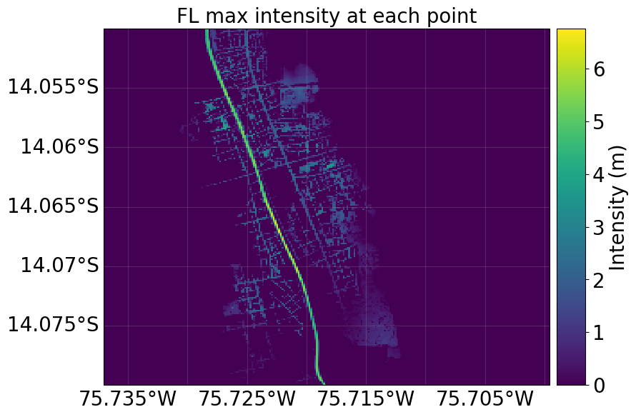

png

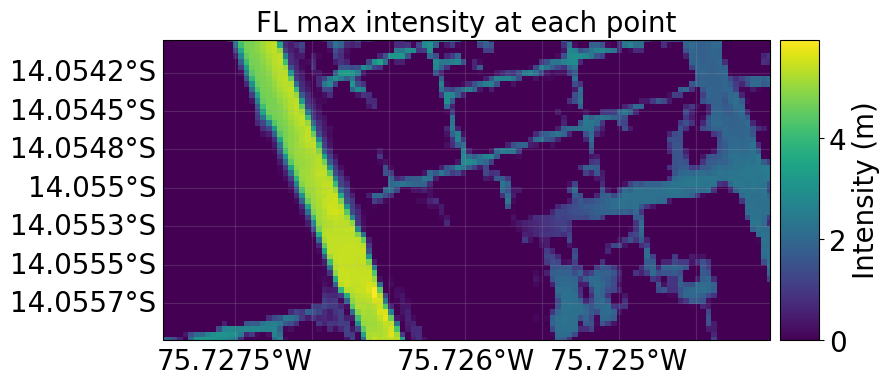

png

```python
# Let's zoom in and plot some smaller areas:

# Central Ica region
extent_ica_centre = (-75.765, -75.683, -14.08, -14.05)  # (min_lon, max_lon, min_lat, max_lat)
lon_min, lon_max, lat_min, lat_max = extent_ica_centre

haz_ica_centre = copy.deepcopy(haz)
haz_ica_centre = haz_ica_centre.select(extent=extent_ica_centre)

_ = haz_ica_centre.plot_intensity(event=0)

# Zoomed to a few streets
extent_ica_streets = (-75.728, -75.724, -14.056, -14.054)  # (min_lon, max_lon, min_lat, max_lat)
lon_min, lon_max, lat_min, lat_max = extent_ica_streets

haz_ica_streets = copy.deepcopy(haz)
haz_ica_streets = haz_ica_streets.select(extent=extent_ica_streets)

_ = haz_ica_streets.plot_intensity(event=0, smooth=False)
```

## 4.3 Hazard object structure

The Hazard is defined through a few key properties: - `centroids`: a CLIMADA Centroids object, which specifies the geographic points on which the hazard’s events are all defined - `intensity`: a sparse matrix, with dimensions (number of events) x (number of centroids), specifying the intensity of the hazard for each location and each event. (A sparse matrix is an efficient way to store matrices where many entries might be zero, which is the case for many hazards, including floods) - `fraction`: another sparse matrix with the same dimensions, this time specifying the fraction of the assets affected by each event at each location. In this study we assume that all exposures are affected, so this matrix isn’t required. - `frequency`: an array giving the probabilistic frequency of each event. We defined these above

The underlying centroids can be visualized:

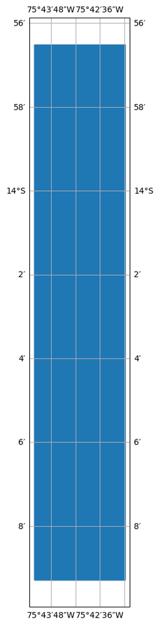

png

```python
_ = haz.centroids.plot(markersize=0.0001)
```

## 4.4 Subsetting centroids

Unusually for a CLIMADA simulation, we want to remove locations with zero modelled hazard. This is because the flood simulation’s very detailed DEM treats the roofs of houses as ‘raised ground’ sets the hazard there to zero.

We solve this by removing model centroids that are located within the housing polygons – i.e. we want rooftops to be missing values rather than 0 values. When CLIMADA matches building exposures to the nearest point of flood data (see the next notebook) it is then forced use flood depths from the streets outside.

```python
# Drop hazard centroids with low or zero hazard
intensity_threshold = 0.05       # [5 cm and less we'll ignore. Maybe this should be 0. Maybe this should be more – you can experiment]
ix = haz.intensity.max(axis=0) < intensity_threshold    # Use the hazard intensity matrix to identify centroids
assert ix.sum() > 0     # Ensure this hasn't removed all cpoints
ix = ix.todense().A1  # Convert from sparse matrix to 1D array of booleans
# Remove any grid cells with zero intensity across all events
haz.centroids.gdf["region_id"] = ix.astype(int)   # (bit hacky) set the hazard's centroid region IDs to 0 (centroid affected) or 1 (centroid never affected)
haz = haz.select(reg_id=0)  # Subset the Hazard to only include grid cells with non-zero intensity across all events
```

```
/usr/local/Caskroom/miniforge/base/envs/climada_env/lib/python3.11/site-packages/scipy/sparse/_base.py:463: SparseEfficiencyWarning: Comparing a sparse matrix with a scalar greater than zero using < is inefficient, try using >= instead.
  return self.tocsr().__lt__(other)
```

Now we can plot the updated hazard, with the missing area.

**Note:** When CLIMADA visualizes hazards it smooths the plot and fills an area around centroids with interpolated hazard values. This creates visual artefacts in datasets with irregular centroids like this one.

- If you want to look at the information at a pixel level, it’s best to plot with a rasterio method as above, or open the raw .tif file in GIS software.
- CLIMADA v6.1.0 and later allow you to set the `mask_distance` parameter in `Hazard.plot_intensity` which extends or reduces the size of the filled area.

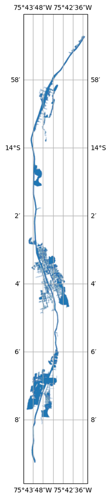

png

png

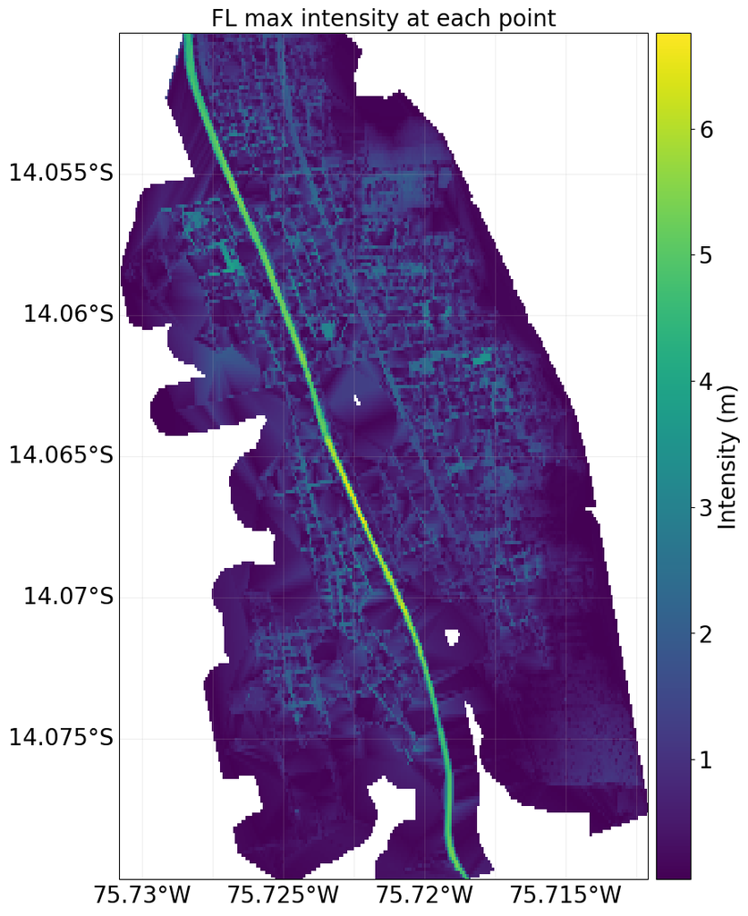

png

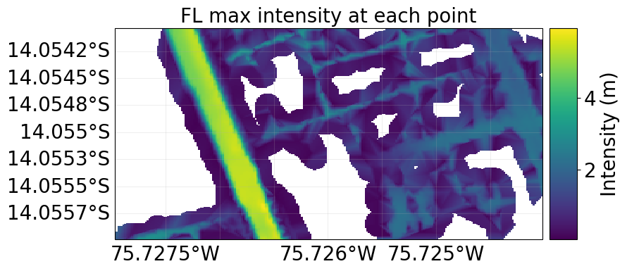

png

```python
# This then changes the hazard plots:

# First we can see the reduced set of centroids:
_ = haz.centroids.plot(markersize=0.0001)

# And the new hazard plots

_ = haz.plot_intensity(event=0)

# Central Ica region
extent_ica_centre = (-75.765, -75.683, -14.08, -14.05)  # (min_lon, max_lon, min_lat, max_lat)
lon_min, lon_max, lat_min, lat_max = extent_ica_centre

haz_ica_centre = copy.deepcopy(haz)
haz_ica_centre = haz_ica_centre.select(extent=extent_ica_centre)

_ = haz_ica_centre.plot_intensity(event=0)

# Zoomed to a few streets
extent_ica_streets = (-75.728, -75.724, -14.056, -14.054)  # (min_lon, max_lon, min_lat, max_lat)
lon_min, lon_max, lat_min, lat_max = extent_ica_streets

haz_ica_streets = copy.deepcopy(haz)
haz_ica_streets = haz_ica_streets.select(extent=extent_ica_streets)

_ = haz_ica_streets.plot_intensity(event=0, smooth=False)
```

# 5 Uncalibrated risk calculations

This notebook will walk through the a risk calculation in CLIMADA with the uncalibrated data.

It will read in data, create the CLIMADA objects needed for the analysis, run the risk calculation, and explore the outputs including plots and statistics.

This analysis is being performed with the *uncalibrated* Entity files containing our first guess impact functions. Therefore the purpose of this notebook is also to notice the shortcomings of the analysis and identify how it has to be improved.

```python
from pathlib import Path

# Set up paths to data
ENTITY_DIR = "../data/entity_files_uncalibrated/"
ENTITY_FILES = ["ICA_PERU_Entity_Floods_Residential.xlsx", "ICA_PERU_Entity_Floods_People.xlsx", "ICA_PERU_Entity_Floods_Road.xlsx"]
entity_filepaths = [Path(ENTITY_DIR) / filename for filename in ENTITY_FILES]

HAZARD_DIR = "../data/hazard/"
HAZARD_FILES = ["tr10_h_max_61200_4326.tif", "tr25_h_max_61200_4326.tif", "tr50_h_max_61200_4326.tif", "tr100_h_max_61200_4326.tif", "tr200_h_max_61200_4326.tif", "tr500_h_max_72000_4326.tif"]
haz_filepaths = [Path(HAZARD_DIR) / filename for filename in HAZARD_FILES]
```

## 5.1 Read in data

### 5.1.1 Entity files

```python
import copy
from climada.entity import Entity

RESIDENCE_VALUE_USD = 97398     # Value of a home chosen from the literature
RESIDENCE_RECOVERY_USD = 4300   # Cost to repair and refit a damaged home, from government statistics
RESIDENCE_REBUILD_USD = 6300    # Cost to rebuild a destroyed home, from government statistics

ROAD_KM_VALUE_USD = 1000000     # Cost to rebuild a km of damaged road, from government statistics


# Read the Entity file and set additional metadata for the Exposures
entity_list = []
for entity_path in entity_filepaths:
    print(f"Reading {entity_path.name}...")
    entity = Entity.from_excel(entity_path)
    entity.exposures.ref_year = 2026
    entity.exposures.value_unit = "People" if "People" in entity_path.name else "USD"   # This needs to be specified but will be read from the Excel file after the next release
    entity.exposures.description = f"Exposures from {entity_path.name}"
    entity_list.append(entity)

entity_residences, entity_people, entity_roads = entity_list
entity_names = ["residences (economic impact)", "people (affected)", "roads (economic impact)"]
```

```
Reading ICA_PERU_Entity_Floods_Residential.xlsx...
Reading ICA_PERU_Entity_Floods_People.xlsx...
Reading ICA_PERU_Entity_Floods_Road.xlsx...
```

### 5.1.2 Plot exposures

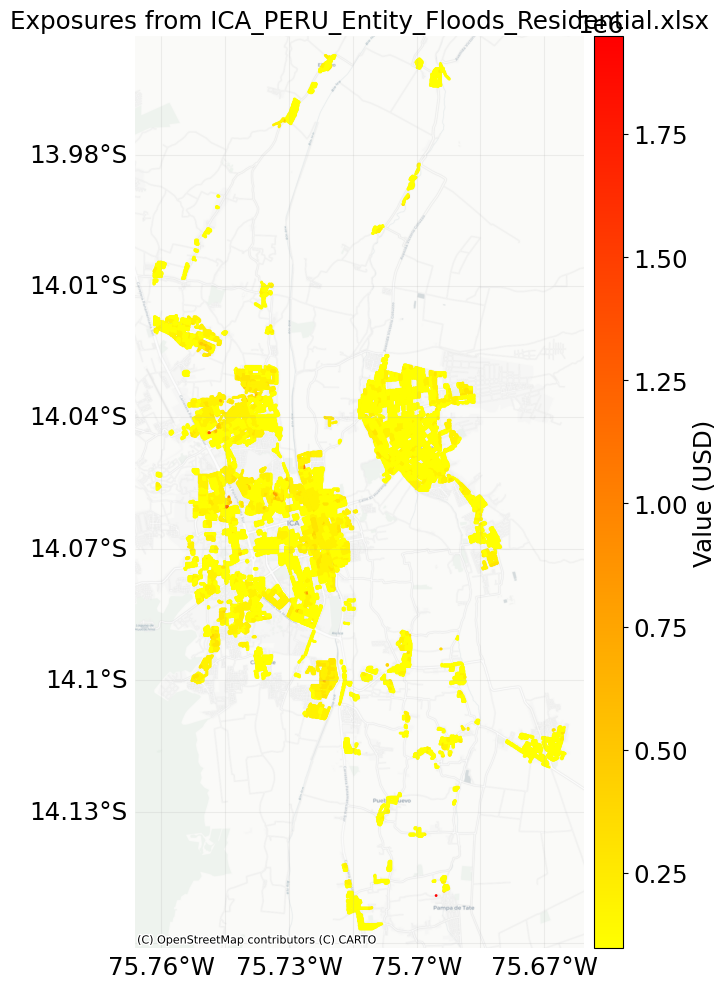

png

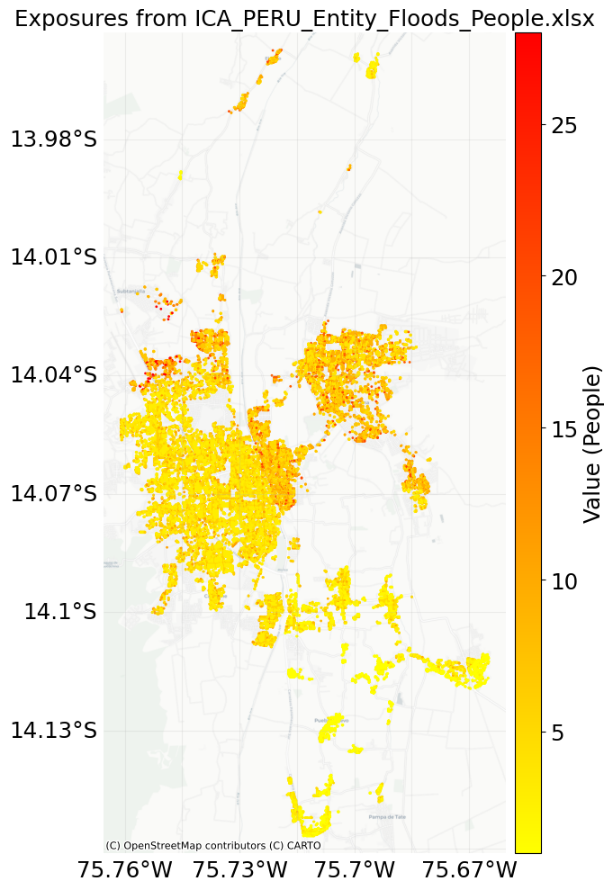

png

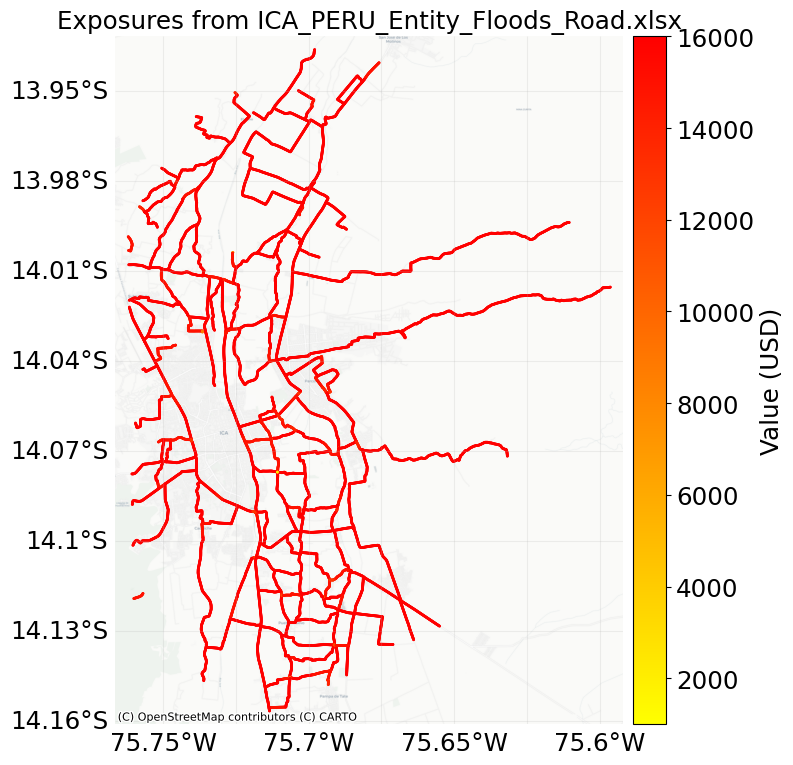

png

```python
%matplotlib inline

for entity in entity_list:
    entity.exposures.plot_basemap(
        title=entity.exposures.description,
        ignore_zero=True,       # Whether to plot points with zero value
        buffer=500,              # Add a buffer around the points to show a larger map region (measured in meters)
        s=1,                     # The size of point markers on the plot
        zoom=14,                 # The detail level of the map. 6 is good for a large country. 8 is good for a state or region. 13 for a city. 15 for a municipality.
        pop_name=False,          # Add the names of populated places to the map – often not necessary when you have a basemap
        vmax=None,               # Set the maximum value for the colour scale – use this if you want a consistent scheme across multiple plots.
        cmap="autumn_r",         # Colour scheme to use for the points. See https://matplotlib.org/stable/tutorials/colors/colormaps.html for options.
        figsize=(8, 10)         # Dimensions of the output figure
    )
```

### 5.1.3 Plot impact functions

- The Residential Entity file contains three first-guess impact functions: a generalized damage curve for economic impacts, and two step functions that count affected and destroyed housing.
- The People Entity file contains two first-guess impact functions: step functions that count people affected and ‘victims’ – roughly corresponding to people who were displaced from their homes.
- The Roads Entity file contains a single first-guess impact function.

png

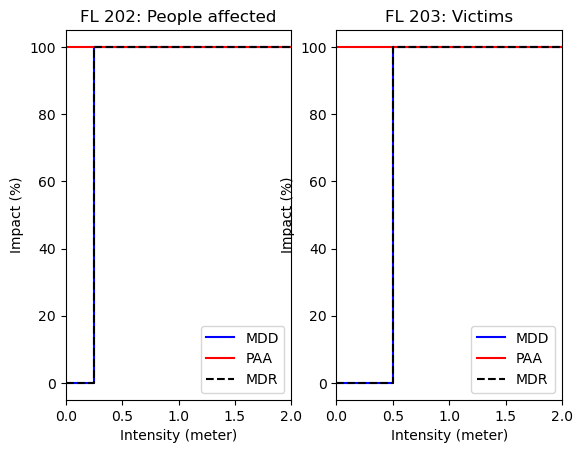

png

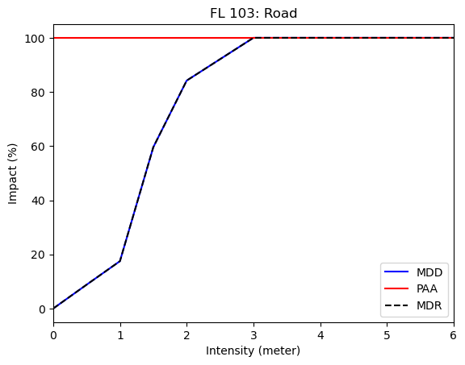

png

```python
for entity in entity_list:
    entity.impact_funcs.plot()
```

### 5.1.4 Hazard

```python
import copy
import numpy as np
from climada.hazard import Hazard

# Read the hazard data

# Since we're reading hazard data from .tif files, we need to provide some additional metadata, including a frequency for each event
# As shown in the Hazard notebook, we have to convert return period frequencies to event frequencies:
HAZARD_RETURN_PERIODS = [10, 25, 50, 100, 200, 500]

def event_frequency_from_return_periods(return_periods):
    rp_rev = copy.deepcopy(return_periods)[::-1]  # Reverse the list so that it's in order of increasing frequency (decreasing return period)
    exceedance_frequency = np.array([1/rp for rp in rp_rev])
    event_frequency = np.diff(np.concatenate([[0], exceedance_frequency]))
    event_frequency = event_frequency[::-1]  # Reverse the frequencies so that they match the order of the events in the hazard file again
    return event_frequency

event_frequency = event_frequency_from_return_periods(HAZARD_RETURN_PERIODS)


# Read in the hazard data
haz = Hazard.from_raster(
    files_intensity = haz_filepaths,
    attrs={
        'unit': 'm',
        'event_name': [f'Return period {rp}' for rp in HAZARD_RETURN_PERIODS],     # We can optionally name the events
        'frequency': event_frequency                                         # For probabilistic analyses we have to define the frequency of each event
    },
    haz_type='FL',
    window=None,          # Only read a window from the raster datasets, provided as a rasterio.windows.Windows object
    geometry=None,        # Only read within a given geometry, provided as a list of shapely.geometry objects
)
```

```
2026-07-03 09:32:48,565 - climada.util.coordinates - INFO - Reading ../data/hazard/tr10_h_max_61200_4326.tif
2026-07-03 09:32:54,755 - climada.util.coordinates - INFO - Reading ../data/hazard/tr10_h_max_61200_4326.tif
2026-07-03 09:32:54,896 - climada.util.coordinates - INFO - Reading ../data/hazard/tr25_h_max_61200_4326.tif
2026-07-03 09:32:55,079 - climada.util.coordinates - INFO - Reading ../data/hazard/tr50_h_max_61200_4326.tif
2026-07-03 09:32:55,264 - climada.util.coordinates - INFO - Reading ../data/hazard/tr100_h_max_61200_4326.tif
2026-07-03 09:32:55,443 - climada.util.coordinates - INFO - Reading ../data/hazard/tr200_h_max_61200_4326.tif
2026-07-03 09:32:55,621 - climada.util.coordinates - INFO - Reading ../data/hazard/tr500_h_max_72000_4326.tif
```

[figure not shown]

png

```python
import rasterio
import matplotlib.pyplot as plt
import contextily as ctx

# Plot most intense values from all events
# (This can be _very_ slow: the hazard is a very large dataset, and CLIMADA is slow to visualize it)
# _ = haz.plot_intensity(event=0)

# Instead: plot the highest return period raster file using rasterio and matplotlib directly
raster_path = haz_filepaths[-1]

with rasterio.open(raster_path) as src:
    raster_data = src.read(1, masked=True)

    bounds = src.bounds
    extent = [bounds.left, bounds.right, bounds.bottom, bounds.top]
    raster_crs = src.crs

fig, ax = plt.subplots(figsize=(10, 8))

# Set map extent to raster bounds (in raster CRS, EPSG:4326 here)
ax.set_xlim(extent[0], extent[1])
ax.set_ylim(extent[2], extent[3])

# Add basemap
ctx.add_basemap(ax, crs=raster_crs, source=ctx.providers.CartoDB.Positron, zoom=13)

# Overlay raster
img = ax.imshow(
    raster_data,
    extent=extent,
    cmap="viridis",
    origin="upper",
)

plt.colorbar(img, ax=ax, label="Flood depth (m)")
ax.set_title(f"Ica 500-year flood depth")
plt.show()
```

```python
# Drop hazard centroids with zero hazard

# Unusually for a CLIMADA simulation, we want to remove locations with zero modelled hazard. This is because the flood simulation's very detailed DEM recognises the roofs of houses and doesn't model hazard at these locations.
# We solve this by removing centroids located within the housing polygons – and anywhere else that never experiences a hazard – we want rooftops to be _missing_ values rather than _zero_ values, forcing CLIMADA to use flood information from non-missing locations, i.e. the nearby streets.

intensity_threshold = 0.05       # [5 cm and less we'll ignore. Maybe this should be 0. Maybe this should be more – you can experiment]
ix = haz.intensity.max(axis=0) < intensity_threshold    # Use the hazard intensity matrix to identify centroids
assert ix.sum() > 0     # Ensure this hasn't removed all cpoints
ix = ix.todense().A1  # Convert from sparse matrix to 1D array of booleans
# Remove any grid cells with zero intensity across all events
haz.centroids.gdf["region_id"] = ix.astype(int)   # (bit hacky) set the hazard's centroid region IDs to 0 (centroid affected) or 1 (centroid never affected)
haz = haz.select(reg_id=0)  # Subset the Hazard to only include grid cells with non-zero intensity across all events
```

```
/usr/local/Caskroom/miniforge/base/envs/climada_env/lib/python3.11/site-packages/scipy/sparse/_base.py:463: SparseEfficiencyWarning: Comparing a sparse matrix with a scalar greater than zero using < is inefficient, try using >= instead.
  return self.tocsr().__lt__(other)
```

```python
# Plot most intense values from all events
# (this is faster now that we've removed zero-hazard centroids)
_ = haz.plot_intensity(event=0)
```

png

## 5.2 Map Hazard centroids to Exposure points

When CLIMADA is given a hazard and an exposure dataset it has to infer the value of the hazard at every exposure point. Often the hazard centroids and the exposure locations do not line up exactly. In these cases, CLIMADA finds the closest hazard centroid for each exposure, within a certain maximum search distance, set by a `threshold` parameter (or estimated by the model if not provided).

Usually CLIMADA’s automated estimate can do this matching well. But sometimes you want to set this manually, most commonly when - The hazard data is not defined on a regular grid, or - The hazard data has a lot of missing values (rather than 0 values), or - The hazard is very detailed – as here

The hazard in this dataset is so detailed that many buildings with a flooded street outside are not close enough to a flooded pixel for CLIMADA’s automated centroid assignment to register the buiolding as affected. So we need to specify the search distance manually.

Here we can visualise that process.

Search distances that are too high will result in flooded properties that are unreastically far from any hazard. Search distances that are too low will result in not enough properties being registered as flooded.

In the plots created below, exposed points are plotted alongside hazard centroids and shaded according to whether they have been mapped to a nearby hazard centroid, with a different matching threshold in each plot. Points in blue have been matched to a nearby centroid whereas points in red are considered to be unaffected.

```python
import pandas as pd
import cartopy.crs as ccrs
from matplotlib import pyplot as plt

# Test different distance thresholds for matching exposures to hazard centroids
distance_thresholds_to_test = [None, 0.0001, 0.0002, 0.0003, 0.0004]
# Zoom in to a very small area for the visualization
extent_streetlevel = (-75.728, -75.724, -14.056, -14.054)  # (min_lon, max_lon, min_lat, max_lat)

# Copy and subset the hazard to this small area
haz_streetlevel = copy.deepcopy(haz)
haz_streetlevel = haz_streetlevel.select(extent=extent_streetlevel)

# Take the housing Entity for this example, and subset to the same small area
def subset_exposures_to_extent(exposures, extent):
    lon_min, lon_max, lat_min, lat_max = extent
    exposures_streetlevel = copy.deepcopy(exposures)
    new_gdf = copy.deepcopy(exposures_streetlevel.gdf)
    sel_ix = (
                (exposures_streetlevel.longitude >= lon_min)
                & (exposures_streetlevel.longitude <= lon_max)
                & (exposures_streetlevel.latitude >= lat_min)
                & (exposures_streetlevel.latitude <= lat_max)
            )
    new_gdf = new_gdf[sel_ix]
    exposures_streetlevel.set_gdf(new_gdf)
    return exposures_streetlevel

residences_zoom = subset_exposures_to_extent(entity_residences.exposures, extent_streetlevel)

# A method to assign hazard centroids to the exposures according to a distance threshold and plot the results
def plot_exposures_within_threshold(haz, exposures_streetlevel, dist_threshold, figsize=(8, 10)):
    exp_thresh = copy.deepcopy(exposures_streetlevel)
    # Match exposures to hazard centroids within the threshold distance
    exp_thresh.assign_centroids(hazard=haz, threshold=dist_threshold, overwrite=True)
    # Label the matched points in the Exposures geodataframe
    new_gdf = exp_thresh.gdf.copy()
    new_gdf["value"] = exp_thresh.hazard_centroids(haz_type="FL") == -1
    exp_thresh.set_gdf(new_gdf)
    # Plot the matched points
    title = f"Threshold distance: {dist_threshold} deg" if dist_threshold is not None else "Automatic threshold estimation"
    axis = exp_thresh.plot_basemap(
        title=title,
        ignore_zero=False,       # Whether to plot points with zero value
        buffer=8,                # Add a buffer around the points to show a larger map region (measured in meters)
        s=3,                     # The size of point markers on the plot
        zoom=17,                 # The detail level of the map. 6 is good for a large country. 8 is good for a state or region. 13 for a city. 15 for a municipality.
        pop_name=False,          # Add the names of populated places to the map – often not necessary when you have a basemap
        vmax=1,               # Set the maximum value for the colour scale – use this if you want a consistent scheme across multiple plots.
        cmap="bwr",         # Colour scheme to use for the points. See https://matplotlib.org/stable/tutorials/colors/colormaps.html for options.
        figsize=figsize,        # Dimensions of the output figure
    )
    haz.centroids.gdf.plot(ax=axis, transform=ccrs.PlateCarree(), color="lightblue", alpha=0.5, markersize=3, label="Hazard centroids")
    return axis

for dist_threshold in distance_thresholds_to_test:
    _ = plot_exposures_within_threshold(haz_streetlevel, residences_zoom, dist_threshold, figsize=(8, 10))
```

```
2026-07-03 09:33:12,465 - climada.entity.exposures.base - INFO - Matching 209 exposures with 2094 centroids.
2026-07-03 09:33:12,473 - climada.util.coordinates - INFO - No exact centroid match found. Reprojecting coordinates to nearest neighbor closer than the threshold = 7.237582121888408e-05 degree
2026-07-03 09:33:12,478 - climada.util.coordinates - WARNING - Distance to closest centroid is greater than 0.000072 degree for 105 coordinates.
2026-07-03 09:33:13,078 - climada.entity.exposures.base - INFO - Matching 209 exposures with 2094 centroids.
2026-07-03 09:33:13,082 - climada.util.coordinates - INFO - No exact centroid match found. Reprojecting coordinates to nearest neighbor closer than the threshold = 0.0001 degree
2026-07-03 09:33:13,086 - climada.util.coordinates - WARNING - Distance to closest centroid is greater than 0.000100 degree for 70 coordinates.
2026-07-03 09:33:13,537 - climada.entity.exposures.base - INFO - Matching 209 exposures with 2094 centroids.
2026-07-03 09:33:13,543 - climada.util.coordinates - INFO - No exact centroid match found. Reprojecting coordinates to nearest neighbor closer than the threshold = 0.0002 degree
2026-07-03 09:33:13,547 - climada.util.coordinates - WARNING - Distance to closest centroid is greater than 0.000200 degree for 25 coordinates.
2026-07-03 09:33:14,012 - climada.entity.exposures.base - INFO - Matching 209 exposures with 2094 centroids.
2026-07-03 09:33:14,017 - climada.util.coordinates - INFO - No exact centroid match found. Reprojecting coordinates to nearest neighbor closer than the threshold = 0.0003 degree
2026-07-03 09:33:14,021 - climada.util.coordinates - WARNING - Distance to closest centroid is greater than 0.000300 degree for 12 coordinates.
2026-07-03 09:33:14,473 - climada.entity.exposures.base - INFO - Matching 209 exposures with 2094 centroids.
2026-07-03 09:33:14,478 - climada.util.coordinates - INFO - No exact centroid match found. Reprojecting coordinates to nearest neighbor closer than the threshold = 0.0004 degree
2026-07-03 09:33:14,481 - climada.util.coordinates - WARNING - Distance to closest centroid is greater than 0.000400 degree for 4 coordinates.
```

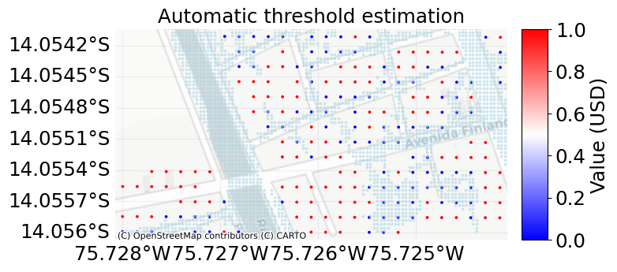

png

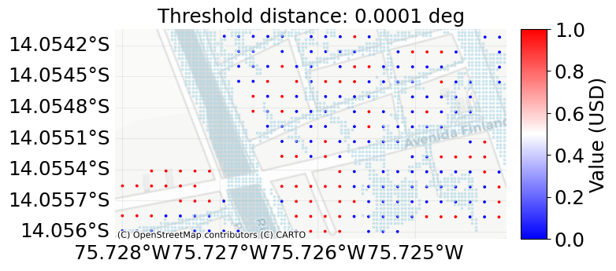

png

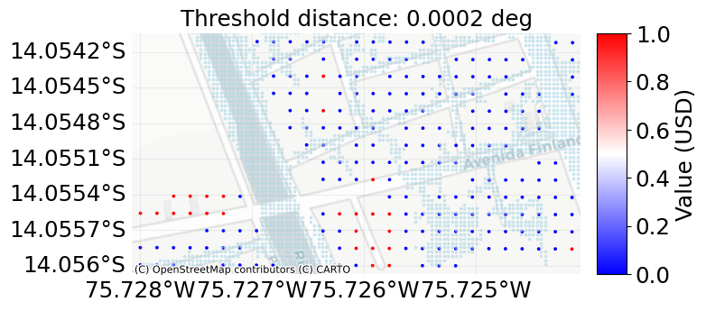

png

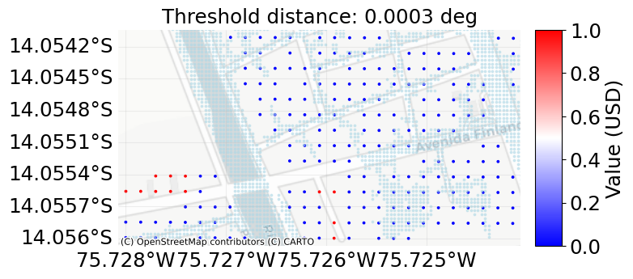

png

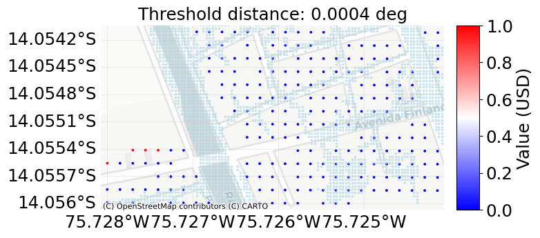

png

From this it looks like a good threshold is 0.0002 – at this matching distances we see that most of a housing block is affected by a nearby flooded street, but neighbouring streets without flooding are unaffected. (Further work could investigate the sensitivity of the calibration and results to this choice of threshold.)